# Tugas Pertemuan 4

Yasmin Azimah Wafa

2023-09-21

## White Noise

*White noise* dibangkitkan dari suatu peubah acak, umumnya peubah acak normal.

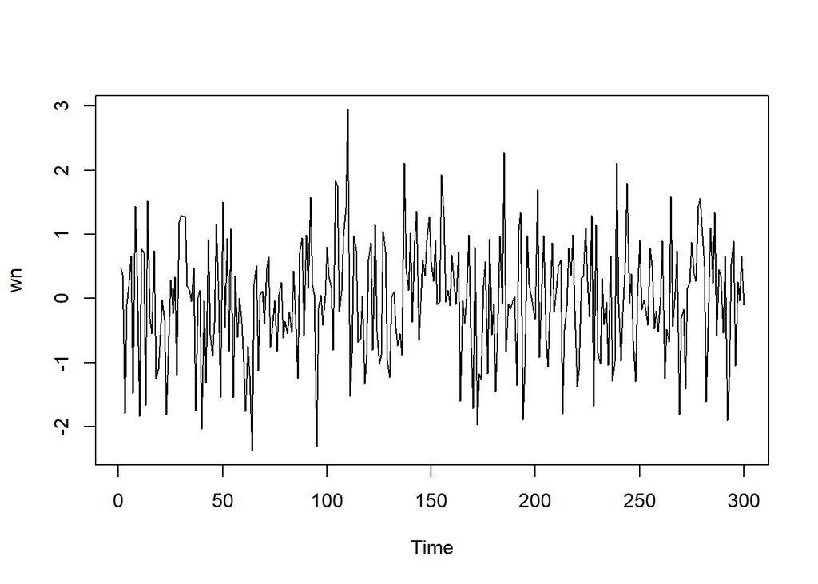

```r
wn <- rnorm(300)
ts.plot(wn)
```

### 1. MA(2) ## Membangkitkan model MA (2) dengan teta1=0.4 dan teta2=0.6 sebanyak 300 data (manualdan dengan arima.sim)

Akan dicoba membangkitkan proses MA(2) dengan $\theta_{1} = 0.4$ dan $\theta_{2} = 0.6$ sebanyak 300 observasi dan $c=0$. Karena diperlukan satu nilai awal untuk $e_{t-1}$ dan $e_{t-2}$, maka masukkan nilai pertama white noise sebagai nilai awal tersebut.

```r
set.seed(107)
ma <- wn[c(1,2)]
```

Nilai-nilai selanjutnya dapat dicari melalui *loop*. Bentuk loop dapat dilihat dari rumus MA(2) yang hendak dibangkitkan:

$$y_t = e_t+0.4e_{t-1}+0.6e_{t-2}$$

```r
for(i in 3:300){
   ma[i] <- wn[i] + 0.4 * wn[i - 1] + 0.6 * wn[i-2]
}
(ma)
```

```
##   [1]  0.4816453959  0.3699412343 -1.3530728009 -0.5866977575 -0.8297963160
##   [6]  0.7117698061 -1.0449000067  1.2389639321  0.0524100361 -0.8327606131
##  [11]  0.2531087938 -0.0760596264 -0.9188765525  1.2929785528 -0.6969354410
##  [16]  0.2479643330  0.3365834194 -1.2842750321 -1.1588553658 -1.7553788353
##  [21] -0.9119925647 -0.6842233726 -1.9581927531 -1.4998023862 -1.0246002604
##  [26] -0.4630429984  0.4210066721 -1.2084485890  0.9101260168  1.0474005878
##  [31]  2.5018058629  2.5744475655  1.4680859278  0.9764635485  0.1221233448
##  [36]  0.5362610293 -1.5857809916 -0.3997673006 -0.9137082279 -1.9756665913
##  [41] -0.7704648124 -2.5489077543  0.3741898529 -0.9877746672 -0.5716984631
##  [46] -1.0713011931  0.4702578133  0.2134732557 -0.8559590288  0.8727165684
##  [51] -0.7711138723  1.6524531541 -0.7221664567  1.3091162927 -1.6000391106
##  [56]  0.3747405882 -1.3857262212 -0.0333167445 -0.7464657459 -1.1341799950
##  [61] -2.3806798737 -2.0385971137 -2.5526763243 -3.3067095068 -1.4429317066
##  [66] -0.8157066922 -0.7760443540 -0.0797390456 -0.5362599091 -0.3139678443
##  [71]  0.3774047311  0.6010519468 -0.2131091782 -0.2650904493 -0.6267522746
```

[output cut: 45 more lines]

Selain menggunakan cara di atas, pembangkitan proses MA(2) dapat dilakukan dengan fungsi `arima.sim()` sebagai berikut.

```r
ma2 <- arima.sim(list(order=c(0,0,2), ma=c(0.4,0.6)), n=300)
ma2
```

```
## Time Series:
## Start = 1
## End = 300
## Frequency = 1
##   [1] -0.965395547 -0.876019146 -1.454962027 -1.418509987 -1.863169724
##   [6] -1.277828262 -0.263265088  1.977507367  0.524968249  0.843476731
##  [11] -0.137630984  0.628309486  1.147095258  1.808863247  2.036853316
##  [16]  0.261069270  0.626885834  0.962159294  1.092133217  0.989251198
##  [21] -1.087946359 -2.016337687 -0.777732536 -0.505418174  1.519566130
##  [26]  0.792814905 -0.586269808 -0.824846839 -2.559379961 -0.315241639
##  [31]  0.289929589  1.188821802  0.405525604  1.865198021 -0.107839986
##  [36]  1.921502731 -0.233476983  0.305932837 -2.497336882  0.966537078
##  [41] -1.347147728  2.285526321  0.023292212  1.407387600  0.297926840
##  [46]  1.045362619  0.395141769  1.189678979  1.382342313  0.620885099
##  [51]  0.390584618 -2.099056009 -0.909193160 -0.738485327 -2.212584662
```

[output cut: 49 more lines]

## Karakteristik MA(2)

### Plot Time Series

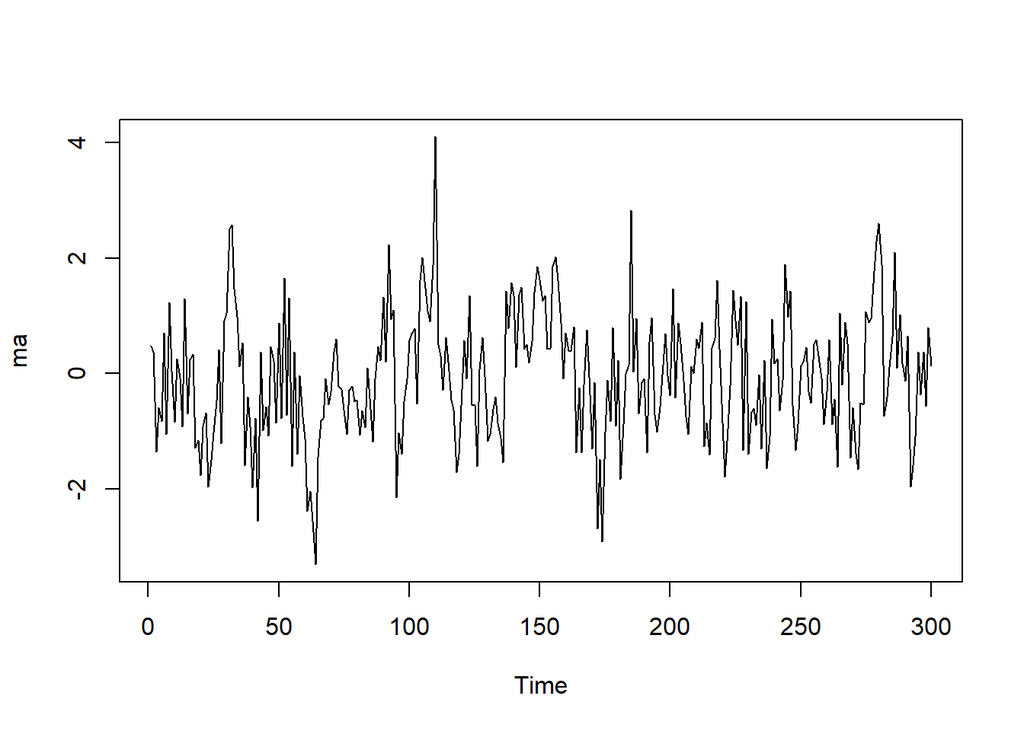

```r
ts.plot(ma)
```

Berdasarkan plot time series, terlihat bahwa data MA(2) yang dibangkitkan stasioner dalam rataan

### Plot ACF

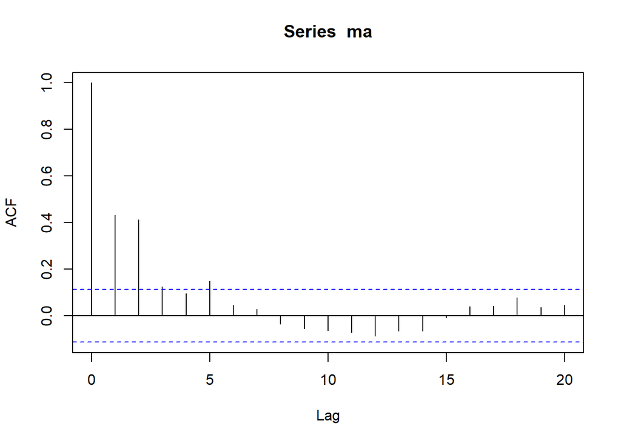

```r
acf(ma,lag.max = 20)
```

### Plot PACF

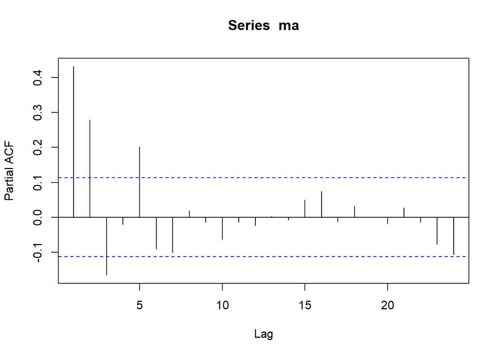

```r
pacf(ma)
```

Berdasarkan plot PACF tersebut, terlihat bahwa plot PACF cenderung *tails off* dan membentuk gelombang sinus

### Plot EACF

```r
TSA::eacf(ma)
```

```
## AR/MA
##   0 1 2 3 4 5 6 7 8 9 10 11 12 13
## 0 x x x o x o o o o o o  o  o  o
## 1 x x x o x o o o o o o  o  o  o
## 2 x x x x x o o o o o o  o  o  o
## 3 x x x o x o o o o o o  o  o  o
## 4 o x x o x o o o o o o  o  o  o
## 5 x x x x x o o o o o o  o  o  o
## 6 x x x o o o o o o o o  o  o  o
## 7 x o x o o o x o x o o  o  o  o
```

### Scatterplot Antar Lag

#### Korelasi antara $Y_t$ dengan $Y_{t-1}$

```r
#Yt
yt_ma <- ma[-1]
yt_ma
```

```
##   [1]  0.3699412343 -1.3530728009 -0.5866977575 -0.8297963160  0.7117698061
##   [6] -1.0449000067  1.2389639321  0.0524100361 -0.8327606131  0.2531087938
##  [11] -0.0760596264 -0.9188765525  1.2929785528 -0.6969354410  0.2479643330
##  [16]  0.3365834194 -1.2842750321 -1.1588553658 -1.7553788353 -0.9119925647
##  [21] -0.6842233726 -1.9581927531 -1.4998023862 -1.0246002604 -0.4630429984
##  [26]  0.4210066721 -1.2084485890  0.9101260168  1.0474005878  2.5018058629
##  [31]  2.5744475655  1.4680859278  0.9764635485  0.1221233448  0.5362610293
##  [36] -1.5857809916 -0.3997673006 -0.9137082279 -1.9756665913 -0.7704648124
##  [41] -2.5489077543  0.3741898529 -0.9877746672 -0.5716984631 -1.0713011931
##  [46]  0.4702578133  0.2134732557 -0.8559590288  0.8727165684 -0.7711138723
##  [51]  1.6524531541 -0.7221664567  1.3091162927 -1.6000391106  0.3747405882
##  [56] -1.3857262212 -0.0333167445 -0.7464657459 -1.1341799950 -2.3806798737
##  [61] -2.0385971137 -2.5526763243 -3.3067095068 -1.4429317066 -0.8157066922
##  [66] -0.7760443540 -0.0797390456 -0.5362599091 -0.3139678443  0.3774047311
##  [71]  0.6010519468 -0.2131091782 -0.2650904493 -0.6267522746 -1.0444713832
```

[output cut: 45 more lines]

```r
#Yt-1
yt_1_ma <- ma[-300]
yt_1_ma
```

```
##   [1]  0.4816453959  0.3699412343 -1.3530728009 -0.5866977575 -0.8297963160
##   [6]  0.7117698061 -1.0449000067  1.2389639321  0.0524100361 -0.8327606131
##  [11]  0.2531087938 -0.0760596264 -0.9188765525  1.2929785528 -0.6969354410
##  [16]  0.2479643330  0.3365834194 -1.2842750321 -1.1588553658 -1.7553788353
##  [21] -0.9119925647 -0.6842233726 -1.9581927531 -1.4998023862 -1.0246002604
##  [26] -0.4630429984  0.4210066721 -1.2084485890  0.9101260168  1.0474005878
##  [31]  2.5018058629  2.5744475655  1.4680859278  0.9764635485  0.1221233448
##  [36]  0.5362610293 -1.5857809916 -0.3997673006 -0.9137082279 -1.9756665913
##  [41] -0.7704648124 -2.5489077543  0.3741898529 -0.9877746672 -0.5716984631
##  [46] -1.0713011931  0.4702578133  0.2134732557 -0.8559590288  0.8727165684
##  [51] -0.7711138723  1.6524531541 -0.7221664567  1.3091162927 -1.6000391106
##  [56]  0.3747405882 -1.3857262212 -0.0333167445 -0.7464657459 -1.1341799950
##  [61] -2.3806798737 -2.0385971137 -2.5526763243 -3.3067095068 -1.4429317066
##  [66] -0.8157066922 -0.7760443540 -0.0797390456 -0.5362599091 -0.3139678443
##  [71]  0.3774047311  0.6010519468 -0.2131091782 -0.2650904493 -0.6267522746
```

[output cut: 45 more lines]

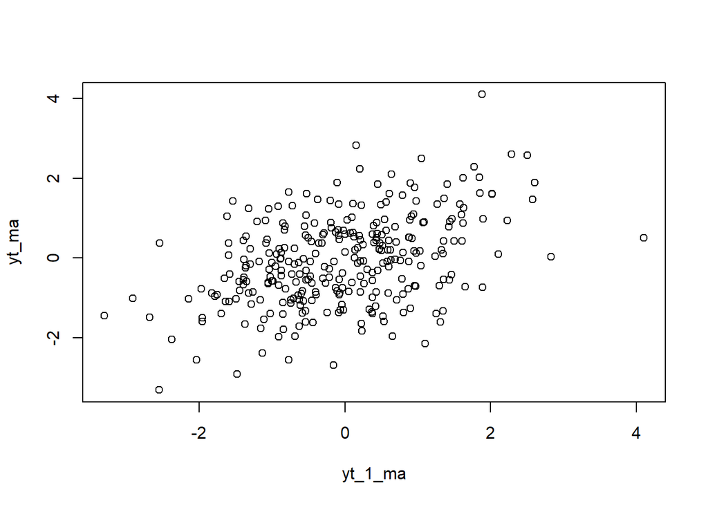

```r
plot(y=yt_ma,x=yt_1_ma)
```

Berdasarkan scatterplot tersebut, terlihat bahwa terdapat hubungan positif antara $Y_t$ dengan $Y_{t-1}$. Hal ini sesuai dengan teori yang ada

```r
cor(yt_ma,yt_1_ma)
```

```
## [1] 0.4315026
```

#### Korelasi antara $Y_t$ dengan $Y_{t-2}$

```r
#Yt
yt_ma2 <- ma[-c(1,2)]
yt_ma2
```

```
##   [1] -1.3530728009 -0.5866977575 -0.8297963160  0.7117698061 -1.0449000067
##   [6]  1.2389639321  0.0524100361 -0.8327606131  0.2531087938 -0.0760596264
##  [11] -0.9188765525  1.2929785528 -0.6969354410  0.2479643330  0.3365834194
##  [16] -1.2842750321 -1.1588553658 -1.7553788353 -0.9119925647 -0.6842233726
##  [21] -1.9581927531 -1.4998023862 -1.0246002604 -0.4630429984  0.4210066721
##  [26] -1.2084485890  0.9101260168  1.0474005878  2.5018058629  2.5744475655
##  [31]  1.4680859278  0.9764635485  0.1221233448  0.5362610293 -1.5857809916
##  [36] -0.3997673006 -0.9137082279 -1.9756665913 -0.7704648124 -2.5489077543
##  [41]  0.3741898529 -0.9877746672 -0.5716984631 -1.0713011931  0.4702578133
##  [46]  0.2134732557 -0.8559590288  0.8727165684 -0.7711138723  1.6524531541
##  [51] -0.7221664567  1.3091162927 -1.6000391106  0.3747405882 -1.3857262212
##  [56] -0.0333167445 -0.7464657459 -1.1341799950 -2.3806798737 -2.0385971137
##  [61] -2.5526763243 -3.3067095068 -1.4429317066 -0.8157066922 -0.7760443540
##  [66] -0.0797390456 -0.5362599091 -0.3139678443  0.3774047311  0.6010519468
##  [71] -0.2131091782 -0.2650904493 -0.6267522746 -1.0444713832 -0.2832900822
```

[output cut: 45 more lines]

```r
#Yt-2
yt_2_ma <- ma[-c(299,300)]
yt_2_ma
```

```
##   [1]  0.4816453959  0.3699412343 -1.3530728009 -0.5866977575 -0.8297963160
##   [6]  0.7117698061 -1.0449000067  1.2389639321  0.0524100361 -0.8327606131
##  [11]  0.2531087938 -0.0760596264 -0.9188765525  1.2929785528 -0.6969354410
##  [16]  0.2479643330  0.3365834194 -1.2842750321 -1.1588553658 -1.7553788353
##  [21] -0.9119925647 -0.6842233726 -1.9581927531 -1.4998023862 -1.0246002604
##  [26] -0.4630429984  0.4210066721 -1.2084485890  0.9101260168  1.0474005878
##  [31]  2.5018058629  2.5744475655  1.4680859278  0.9764635485  0.1221233448
##  [36]  0.5362610293 -1.5857809916 -0.3997673006 -0.9137082279 -1.9756665913
##  [41] -0.7704648124 -2.5489077543  0.3741898529 -0.9877746672 -0.5716984631
##  [46] -1.0713011931  0.4702578133  0.2134732557 -0.8559590288  0.8727165684
##  [51] -0.7711138723  1.6524531541 -0.7221664567  1.3091162927 -1.6000391106
##  [56]  0.3747405882 -1.3857262212 -0.0333167445 -0.7464657459 -1.1341799950
##  [61] -2.3806798737 -2.0385971137 -2.5526763243 -3.3067095068 -1.4429317066
##  [66] -0.8157066922 -0.7760443540 -0.0797390456 -0.5362599091 -0.3139678443
##  [71]  0.3774047311  0.6010519468 -0.2131091782 -0.2650904493 -0.6267522746
```

[output cut: 45 more lines]

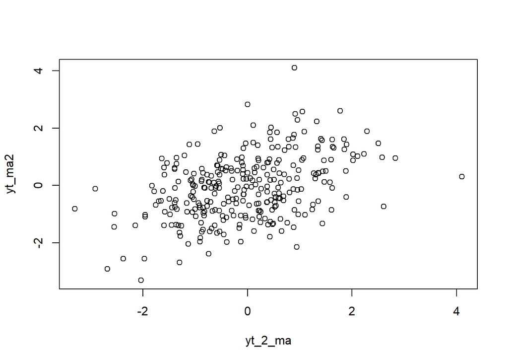

```r
plot(y=yt_ma2,x=yt_2_ma)
```

```r
cor(yt_ma2,yt_2_ma)
```

```
## [1] 0.4135535
```

```r
#Yt
yt_ma3 <- ma[-c(1,2,3)]
yt_ma3
```

```
##   [1] -0.5866977575 -0.8297963160  0.7117698061 -1.0449000067  1.2389639321
##   [6]  0.0524100361 -0.8327606131  0.2531087938 -0.0760596264 -0.9188765525
##  [11]  1.2929785528 -0.6969354410  0.2479643330  0.3365834194 -1.2842750321
##  [16] -1.1588553658 -1.7553788353 -0.9119925647 -0.6842233726 -1.9581927531
##  [21] -1.4998023862 -1.0246002604 -0.4630429984  0.4210066721 -1.2084485890
##  [26]  0.9101260168  1.0474005878  2.5018058629  2.5744475655  1.4680859278
##  [31]  0.9764635485  0.1221233448  0.5362610293 -1.5857809916 -0.3997673006
##  [36] -0.9137082279 -1.9756665913 -0.7704648124 -2.5489077543  0.3741898529
##  [41] -0.9877746672 -0.5716984631 -1.0713011931  0.4702578133  0.2134732557
##  [46] -0.8559590288  0.8727165684 -0.7711138723  1.6524531541 -0.7221664567
##  [51]  1.3091162927 -1.6000391106  0.3747405882 -1.3857262212 -0.0333167445
##  [56] -0.7464657459 -1.1341799950 -2.3806798737 -2.0385971137 -2.5526763243
##  [61] -3.3067095068 -1.4429317066 -0.8157066922 -0.7760443540 -0.0797390456
##  [66] -0.5362599091 -0.3139678443  0.3774047311  0.6010519468 -0.2131091782
##  [71] -0.2650904493 -0.6267522746 -1.0444713832 -0.2832900822 -0.2193770577
```

[output cut: 45 more lines]

```r
#Yt-3
yt_3_ma <- ma[-c(298,299,300)]
yt_3_ma
```

```
##   [1]  0.4816453959  0.3699412343 -1.3530728009 -0.5866977575 -0.8297963160
##   [6]  0.7117698061 -1.0449000067  1.2389639321  0.0524100361 -0.8327606131
##  [11]  0.2531087938 -0.0760596264 -0.9188765525  1.2929785528 -0.6969354410
##  [16]  0.2479643330  0.3365834194 -1.2842750321 -1.1588553658 -1.7553788353
##  [21] -0.9119925647 -0.6842233726 -1.9581927531 -1.4998023862 -1.0246002604
##  [26] -0.4630429984  0.4210066721 -1.2084485890  0.9101260168  1.0474005878
##  [31]  2.5018058629  2.5744475655  1.4680859278  0.9764635485  0.1221233448
##  [36]  0.5362610293 -1.5857809916 -0.3997673006 -0.9137082279 -1.9756665913
##  [41] -0.7704648124 -2.5489077543  0.3741898529 -0.9877746672 -0.5716984631
##  [46] -1.0713011931  0.4702578133  0.2134732557 -0.8559590288  0.8727165684
##  [51] -0.7711138723  1.6524531541 -0.7221664567  1.3091162927 -1.6000391106
##  [56]  0.3747405882 -1.3857262212 -0.0333167445 -0.7464657459 -1.1341799950
##  [61] -2.3806798737 -2.0385971137 -2.5526763243 -3.3067095068 -1.4429317066
##  [66] -0.8157066922 -0.7760443540 -0.0797390456 -0.5362599091 -0.3139678443
##  [71]  0.3774047311  0.6010519468 -0.2131091782 -0.2650904493 -0.6267522746
```

[output cut: 45 more lines]

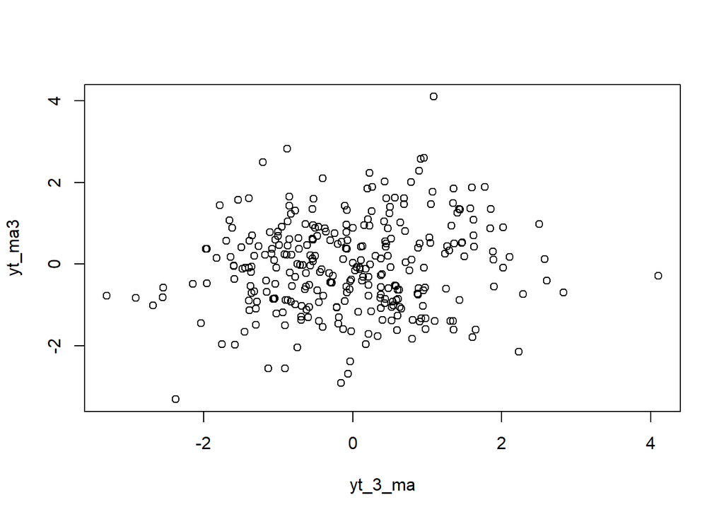

```r
plot(y=yt_ma3,x=yt_3_ma)
```

```r
cor(yt_ma3,yt_3_ma)
```

```
## [1] 0.1253535
```

### 2. AR(2)

## Bangkitkan model AR(2) dengan 𝜙1 = 0.5 dan 𝜙2 = 0.2 sebanyak 300 data (Manual dan dengan arima.sim)

Akan dicoba membangkitkan proses AR, yaitu AR(2) dengan $\phi_{1} = 0.5$ dan $\phi_{2} = 0.2$ sebanyak 300 observasi dan $c=0$.

```r
set.seed(107)
```

Nilai-nilai selanjutnya dapat dicari melalui *loop*. Bentuk loop dapat dilihat dari rumus AR(2) yang hendak dibangkitkan:

```r
n<-length(wn)
n
```

```
## [1] 300
```

```r
ar <- c(1:n)
for (i in 3:n) {ar[i]<-wn[i]+0.5*ar[i-1]+0.2*ar[i-2]}
ar
```

```
##   [1]  1.00000000  2.00000000 -0.59003653  0.01233385  0.16944438  0.74203359
##   [7] -1.07070304  1.04935583  0.67379232 -1.29307567  0.25931361  0.59045065
##  [13] -1.32220789  0.98603773 -0.07840121 -0.38866825  0.52942623 -1.06506669
##  [19] -1.52834936 -1.54065866 -1.10158275 -1.19483068 -2.62621148 -2.12693788
##  [25] -1.29827734 -1.30882320 -0.57360195 -1.75262208  0.19643810  1.04254129
##  [31]  1.83194375  2.41346551  1.76278199  1.49129222  1.05564631  1.30304023
##  [37] -0.88838135 -0.16911282 -0.13111039 -2.13617515 -1.12872888 -2.30466110
##  [43] -0.45801029 -1.25790147 -1.61710524 -1.43203466  0.11751160 -0.25381682
##  [49] -1.64306883  0.63198330 -0.46165077  0.82506724 -0.50434418  0.99407913
##  [55] -1.14163490 -0.03088145 -0.84325862 -0.42599808 -0.76914497 -1.45003892
##  [61] -2.63492508 -2.35547670 -2.90455117 -4.30134549 -2.50342818 -1.59216706
##  [67] -2.41763285 -1.47053308 -1.10522151 -1.24014391 -0.37448387  0.21518420
##  [73] -0.72057525 -0.67130595 -0.51293589 -1.20950027 -0.64321822 -0.31727118
##  [79] -0.90152270 -0.87069565 -1.16355469 -0.96452134 -1.23923640 -0.38403033
##  [85] -0.91023014 -1.78215146 -0.37027924  0.39945648 -0.44425975  0.84402193
```

[output cut: 35 more lines]

Selain menggunakan cara di atas, pembangkitan proses AR dapat dilakukan dengan fungsi `arima.sim()` sebagai berikut.

```r
ar2 <- arima.sim(list(order=c(2,0,0), ar=c(0.5,0.2)), n=300)
ar2
```

```
## Time Series:
## Start = 1
## End = 300
## Frequency = 1
##   [1] -0.230260864  0.938173219  0.688211934 -0.814918294 -0.715106536
##   [6] -2.093805634 -0.608684415  0.278291595  0.456928919 -0.086996577
##  [11]  1.797821256  0.296369436  1.613348194  0.541316438  0.365753779
##  [16] -1.920388146  1.100649538 -0.649060736  1.314633298  0.472367936
##  [21]  1.077132599  0.732839878  1.240475898  0.838615924  1.433180457
##  [26]  1.917258801  0.993506047  0.751725947 -1.322044624 -0.584139458
##  [31] -0.127613762 -2.520687990 -0.922300157 -2.104256035 -2.126521199
##  [36] -0.781788070 -0.985982214  0.691947932  0.410278435  0.910520942
##  [41] -0.133164407  0.989269497  2.557487807  0.906445125  1.546907148
##  [46]  1.353869459  1.630922964 -2.387642434 -2.462255440 -1.718915109
##  [51] -1.111655751  0.678170256 -0.192235359 -1.193854583 -0.168380920
```

[output cut: 49 more lines]

### Plot Time Series

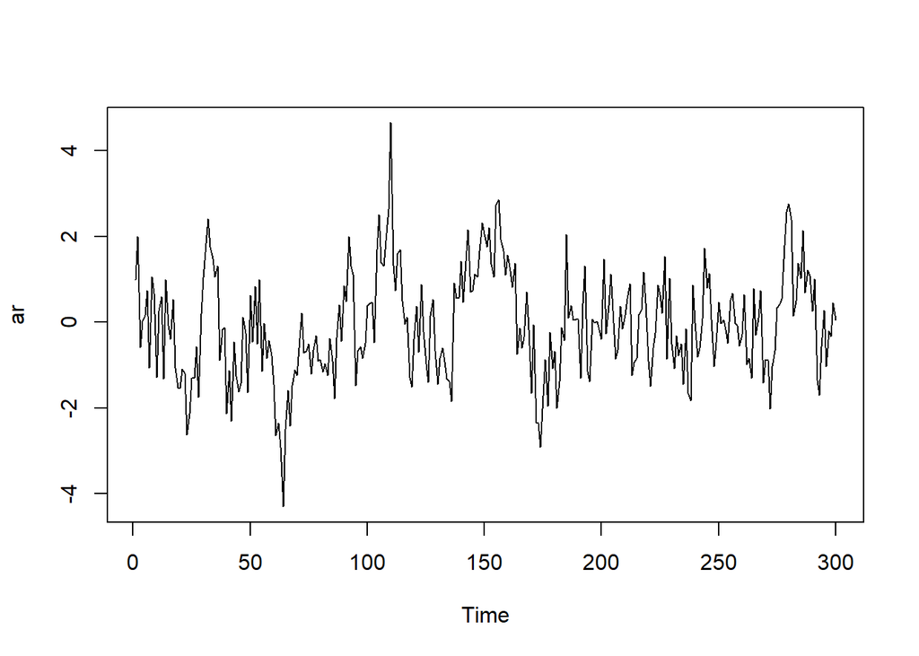

```r
ts.plot(ar)
```

Berdasarkan plot time series tersebut terlihat bahwa data cenderung stasioner pada rataan

### Plot ACF

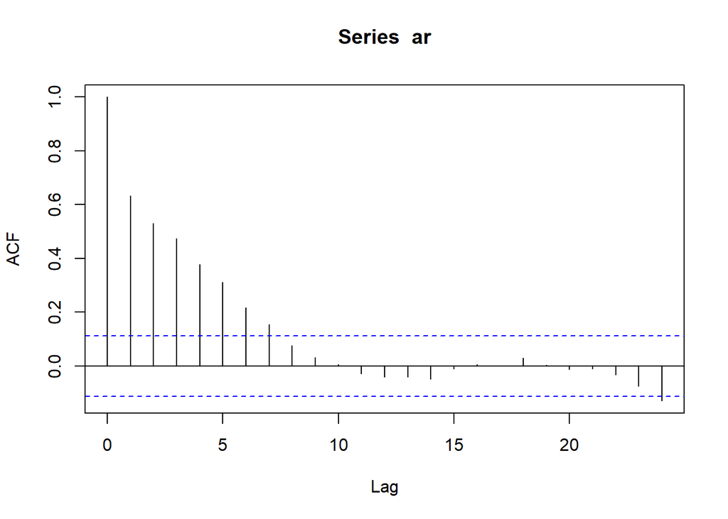

```r
acf(ar)
```

Berdasarkan plot ACF tersebut terlihat bahwa plot ACF cenderung *tails off*

### Plot PACF

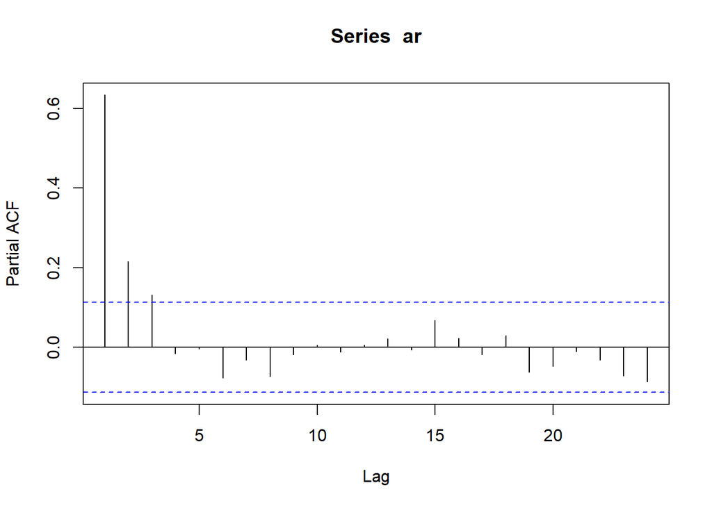

```r
pacf(ar)
```

### Plot EACF

```r
TSA::eacf(ar)
```

```
## AR/MA
##   0 1 2 3 4 5 6 7 8 9 10 11 12 13
## 0 x x x x x x x o o o o  o  o  o
## 1 x o o o o o o o o o o  o  o  o
## 2 x x o o o o o o o o o  o  o  o
## 3 x o x o o o o o o o o  o  o  o
## 4 x o x o o o o o o o o  o  o  o
## 5 o x x o o o o o o o o  o  o  o
## 6 x x x o o x o o o o o  o  o  o
## 7 x x x o o x x o o o o  o  o  o
```

### Scatterplot Antar Lag

#### Korelasi antara $Y_t$ dengan $Y_{t-1}$

```r
#Yt
yt_ar <- ar[-1]
yt_ar
```

```
##   [1]  2.00000000 -0.59003653  0.01233385  0.16944438  0.74203359 -1.07070304
##   [7]  1.04935583  0.67379232 -1.29307567  0.25931361  0.59045065 -1.32220789
##  [13]  0.98603773 -0.07840121 -0.38866825  0.52942623 -1.06506669 -1.52834936
##  [19] -1.54065866 -1.10158275 -1.19483068 -2.62621148 -2.12693788 -1.29827734
##  [25] -1.30882320 -0.57360195 -1.75262208  0.19643810  1.04254129  1.83194375
##  [31]  2.41346551  1.76278199  1.49129222  1.05564631  1.30304023 -0.88838135
##  [37] -0.16911282 -0.13111039 -2.13617515 -1.12872888 -2.30466110 -0.45801029
##  [43] -1.25790147 -1.61710524 -1.43203466  0.11751160 -0.25381682 -1.64306883
##  [49]  0.63198330 -0.46165077  0.82506724 -0.50434418  0.99407913 -1.14163490
##  [55] -0.03088145 -0.84325862 -0.42599808 -0.76914497 -1.45003892 -2.63492508
##  [61] -2.35547670 -2.90455117 -4.30134549 -2.50342818 -1.59216706 -2.41763285
##  [67] -1.47053308 -1.10522151 -1.24014391 -0.37448387  0.21518420 -0.72057525
##  [73] -0.67130595 -0.51293589 -1.20950027 -0.64321822 -0.31727118 -0.90152270
##  [79] -0.87069565 -1.16355469 -0.96452134 -1.23923640 -0.38403033 -0.91023014
##  [85] -1.78215146 -0.37027924  0.39945648 -0.44425975  0.84402193  0.48715167
```

[output cut: 35 more lines]

```r
#Yt-1
yt_1_ar <- ar[-300]
yt_1_ar
```

```
##   [1]  1.00000000  2.00000000 -0.59003653  0.01233385  0.16944438  0.74203359
##   [7] -1.07070304  1.04935583  0.67379232 -1.29307567  0.25931361  0.59045065
##  [13] -1.32220789  0.98603773 -0.07840121 -0.38866825  0.52942623 -1.06506669
##  [19] -1.52834936 -1.54065866 -1.10158275 -1.19483068 -2.62621148 -2.12693788
##  [25] -1.29827734 -1.30882320 -0.57360195 -1.75262208  0.19643810  1.04254129
##  [31]  1.83194375  2.41346551  1.76278199  1.49129222  1.05564631  1.30304023
##  [37] -0.88838135 -0.16911282 -0.13111039 -2.13617515 -1.12872888 -2.30466110
##  [43] -0.45801029 -1.25790147 -1.61710524 -1.43203466  0.11751160 -0.25381682
##  [49] -1.64306883  0.63198330 -0.46165077  0.82506724 -0.50434418  0.99407913
##  [55] -1.14163490 -0.03088145 -0.84325862 -0.42599808 -0.76914497 -1.45003892
##  [61] -2.63492508 -2.35547670 -2.90455117 -4.30134549 -2.50342818 -1.59216706
##  [67] -2.41763285 -1.47053308 -1.10522151 -1.24014391 -0.37448387  0.21518420
##  [73] -0.72057525 -0.67130595 -0.51293589 -1.20950027 -0.64321822 -0.31727118
##  [79] -0.90152270 -0.87069565 -1.16355469 -0.96452134 -1.23923640 -0.38403033
##  [85] -0.91023014 -1.78215146 -0.37027924  0.39945648 -0.44425975  0.84402193
```

[output cut: 35 more lines]

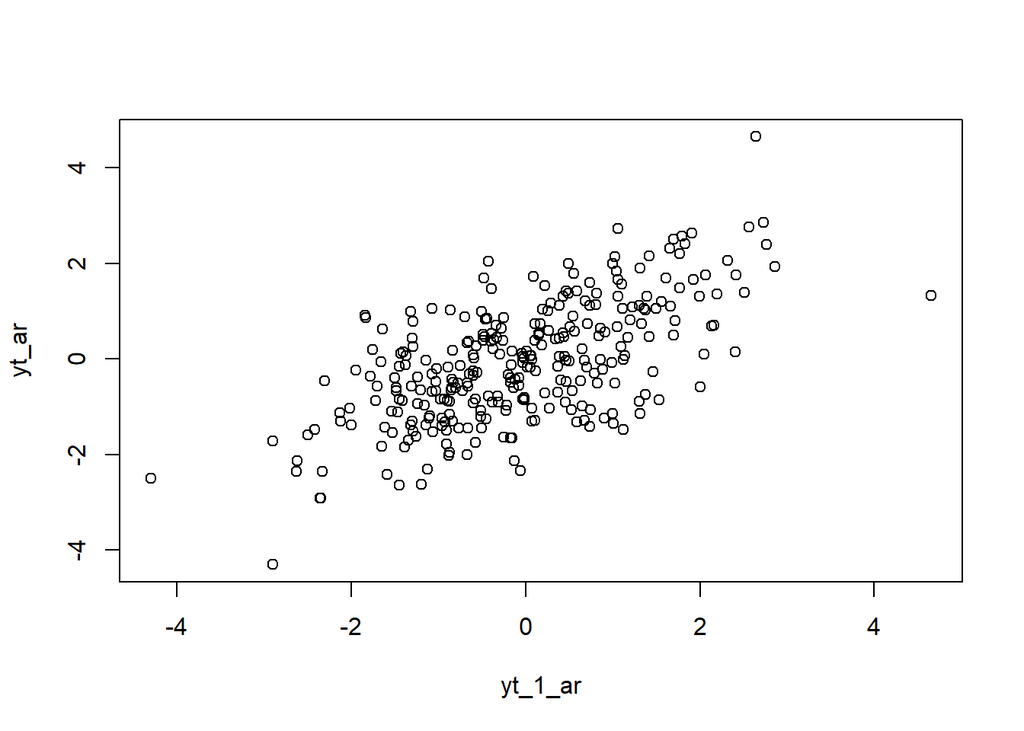

```r
plot(y=yt_ar,x=yt_1_ar)
```

Berdasarkan scatterplot tersebut, terlihat bahwa terdapat hubungan positif antara $Y_t$ dengan $Y_{t-1}$. Hal ini sesuai dengan teori yang ada

```r
cor(yt_ar,yt_1_ar)
```

```
## [1] 0.6342216
```

Korelasi antara $Y_t$ dengan $Y_{t-1}$ dari hasil simulasi mendekati perhitungan teoritis yaitu
$$\rho_1=\frac{\phi_{1}}{1-\phi_{2}}=\frac{0.5}{1-0.2}=0.625$$

#### Korelasi antara $Y_t$ dengan $Y_{t-2}$

```r
#Yt
yt_ar2 <- ar[-c(1,2)]
yt_ar2
```

```
##   [1] -0.59003653  0.01233385  0.16944438  0.74203359 -1.07070304  1.04935583
##   [7]  0.67379232 -1.29307567  0.25931361  0.59045065 -1.32220789  0.98603773
##  [13] -0.07840121 -0.38866825  0.52942623 -1.06506669 -1.52834936 -1.54065866
##  [19] -1.10158275 -1.19483068 -2.62621148 -2.12693788 -1.29827734 -1.30882320
##  [25] -0.57360195 -1.75262208  0.19643810  1.04254129  1.83194375  2.41346551
##  [31]  1.76278199  1.49129222  1.05564631  1.30304023 -0.88838135 -0.16911282
##  [37] -0.13111039 -2.13617515 -1.12872888 -2.30466110 -0.45801029 -1.25790147
##  [43] -1.61710524 -1.43203466  0.11751160 -0.25381682 -1.64306883  0.63198330
##  [49] -0.46165077  0.82506724 -0.50434418  0.99407913 -1.14163490 -0.03088145
##  [55] -0.84325862 -0.42599808 -0.76914497 -1.45003892 -2.63492508 -2.35547670
##  [61] -2.90455117 -4.30134549 -2.50342818 -1.59216706 -2.41763285 -1.47053308
##  [67] -1.10522151 -1.24014391 -0.37448387  0.21518420 -0.72057525 -0.67130595
##  [73] -0.51293589 -1.20950027 -0.64321822 -0.31727118 -0.90152270 -0.87069565
##  [79] -1.16355469 -0.96452134 -1.23923640 -0.38403033 -0.91023014 -1.78215146
##  [85] -0.37027924  0.39945648 -0.44425975  0.84402193  0.48715167  1.99017128
```

[output cut: 35 more lines]

```r
#Yt-2
yt_2_ar <- ar[-c(299,300)]
yt_2_ar
```

```
##   [1]  1.00000000  2.00000000 -0.59003653  0.01233385  0.16944438  0.74203359
##   [7] -1.07070304  1.04935583  0.67379232 -1.29307567  0.25931361  0.59045065
##  [13] -1.32220789  0.98603773 -0.07840121 -0.38866825  0.52942623 -1.06506669
##  [19] -1.52834936 -1.54065866 -1.10158275 -1.19483068 -2.62621148 -2.12693788
##  [25] -1.29827734 -1.30882320 -0.57360195 -1.75262208  0.19643810  1.04254129
##  [31]  1.83194375  2.41346551  1.76278199  1.49129222  1.05564631  1.30304023
##  [37] -0.88838135 -0.16911282 -0.13111039 -2.13617515 -1.12872888 -2.30466110
##  [43] -0.45801029 -1.25790147 -1.61710524 -1.43203466  0.11751160 -0.25381682
##  [49] -1.64306883  0.63198330 -0.46165077  0.82506724 -0.50434418  0.99407913
##  [55] -1.14163490 -0.03088145 -0.84325862 -0.42599808 -0.76914497 -1.45003892
##  [61] -2.63492508 -2.35547670 -2.90455117 -4.30134549 -2.50342818 -1.59216706
##  [67] -2.41763285 -1.47053308 -1.10522151 -1.24014391 -0.37448387  0.21518420
##  [73] -0.72057525 -0.67130595 -0.51293589 -1.20950027 -0.64321822 -0.31727118
##  [79] -0.90152270 -0.87069565 -1.16355469 -0.96452134 -1.23923640 -0.38403033
##  [85] -0.91023014 -1.78215146 -0.37027924  0.39945648 -0.44425975  0.84402193
```

[output cut: 35 more lines]

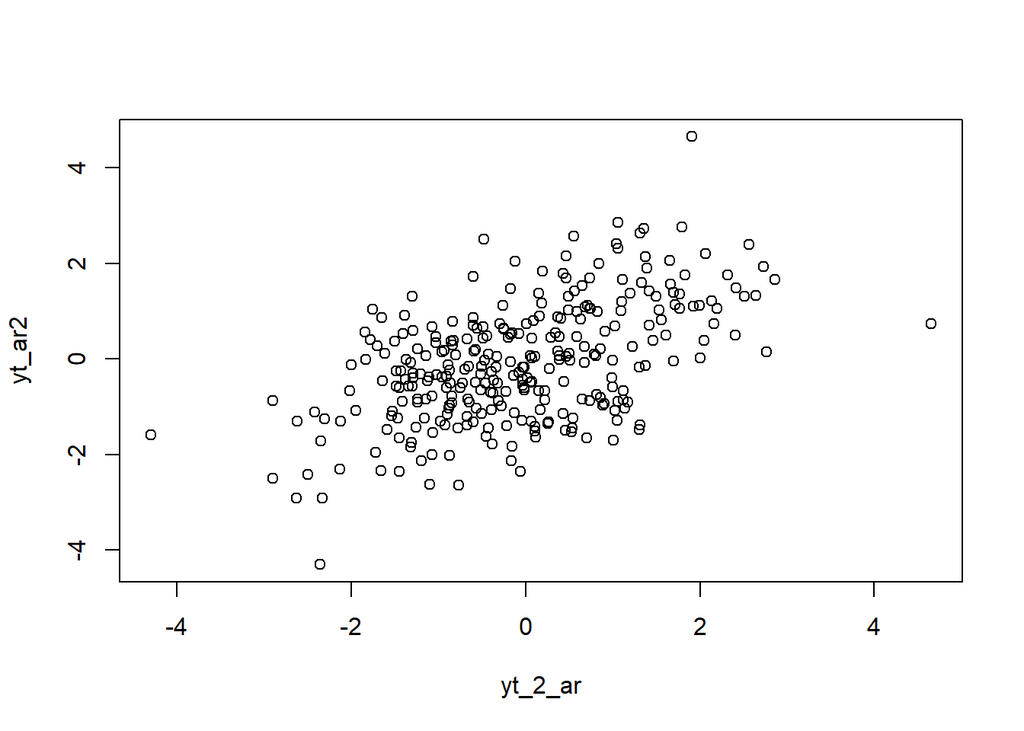

```r
plot(y=yt_ar2,x=yt_2_ar)
```

Berdasarkan scatterplot tersebut, terlihat bahwa terdapat hubungan positif antara $Y_t$ dengan $Y_{t-2}$. Hal ini sesuai dengan teori yang ada

```r
cor(yt_ar2,yt_2_ar)
```

```
## [1] 0.5332432
```

Korelasi antara $Y_t$ dengan $Y_{t-2}$ dari hasil simulasi mendekati perhitungan teoritis yaitu

$$\rho_2=\frac{\phi_{2}(1-\phi_{2})+\phi_{1}^2}{1-\phi_{2}}=\frac{0.2(1-0.2)+0.5^2}{1-0.2}=0.512$$
## Korelasi antara $Y_t$ dengan $Y_{t-3}$

```r
#Yt
yt_ar3 <- ar[-c(1,2,3)]
yt_ar3
```

```
##   [1]  0.01233385  0.16944438  0.74203359 -1.07070304  1.04935583  0.67379232
##   [7] -1.29307567  0.25931361  0.59045065 -1.32220789  0.98603773 -0.07840121
##  [13] -0.38866825  0.52942623 -1.06506669 -1.52834936 -1.54065866 -1.10158275
##  [19] -1.19483068 -2.62621148 -2.12693788 -1.29827734 -1.30882320 -0.57360195
##  [25] -1.75262208  0.19643810  1.04254129  1.83194375  2.41346551  1.76278199
##  [31]  1.49129222  1.05564631  1.30304023 -0.88838135 -0.16911282 -0.13111039
##  [37] -2.13617515 -1.12872888 -2.30466110 -0.45801029 -1.25790147 -1.61710524
##  [43] -1.43203466  0.11751160 -0.25381682 -1.64306883  0.63198330 -0.46165077
##  [49]  0.82506724 -0.50434418  0.99407913 -1.14163490 -0.03088145 -0.84325862
##  [55] -0.42599808 -0.76914497 -1.45003892 -2.63492508 -2.35547670 -2.90455117
##  [61] -4.30134549 -2.50342818 -1.59216706 -2.41763285 -1.47053308 -1.10522151
##  [67] -1.24014391 -0.37448387  0.21518420 -0.72057525 -0.67130595 -0.51293589
##  [73] -1.20950027 -0.64321822 -0.31727118 -0.90152270 -0.87069565 -1.16355469
##  [79] -0.96452134 -1.23923640 -0.38403033 -0.91023014 -1.78215146 -0.37027924
##  [85]  0.39945648 -0.44425975  0.84402193  0.48715167  1.99017128  1.30711257
```

[output cut: 35 more lines]

```r
#Yt-3
yt_3_ar <- ar[-c(298,299,300)]
yt_3_ar
```

```
##   [1]  1.00000000  2.00000000 -0.59003653  0.01233385  0.16944438  0.74203359
##   [7] -1.07070304  1.04935583  0.67379232 -1.29307567  0.25931361  0.59045065
##  [13] -1.32220789  0.98603773 -0.07840121 -0.38866825  0.52942623 -1.06506669
##  [19] -1.52834936 -1.54065866 -1.10158275 -1.19483068 -2.62621148 -2.12693788
##  [25] -1.29827734 -1.30882320 -0.57360195 -1.75262208  0.19643810  1.04254129
##  [31]  1.83194375  2.41346551  1.76278199  1.49129222  1.05564631  1.30304023
##  [37] -0.88838135 -0.16911282 -0.13111039 -2.13617515 -1.12872888 -2.30466110
##  [43] -0.45801029 -1.25790147 -1.61710524 -1.43203466  0.11751160 -0.25381682
##  [49] -1.64306883  0.63198330 -0.46165077  0.82506724 -0.50434418  0.99407913
##  [55] -1.14163490 -0.03088145 -0.84325862 -0.42599808 -0.76914497 -1.45003892
##  [61] -2.63492508 -2.35547670 -2.90455117 -4.30134549 -2.50342818 -1.59216706
##  [67] -2.41763285 -1.47053308 -1.10522151 -1.24014391 -0.37448387  0.21518420
##  [73] -0.72057525 -0.67130595 -0.51293589 -1.20950027 -0.64321822 -0.31727118
##  [79] -0.90152270 -0.87069565 -1.16355469 -0.96452134 -1.23923640 -0.38403033
##  [85] -0.91023014 -1.78215146 -0.37027924  0.39945648 -0.44425975  0.84402193
```

[output cut: 35 more lines]

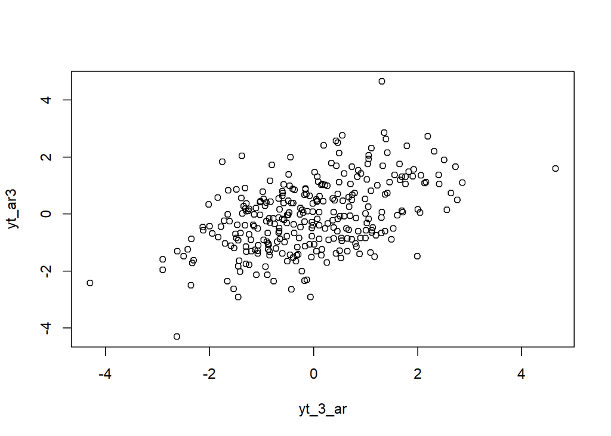

```r
plot(y=yt_ar3,x=yt_3_ar)
```

```r
cor(yt_ar3,yt_3_ar)
```

```
## [1] 0.4780641
```

### 3. ARMA (2,2)

```r
set.seed(107)
n = length(wn)
phi1 = 0.5
phi2 = 0.2
theta1 = 0.4
theta2 = 0.6

y.arma=c(1:n)
for(i in 3:n){y.arma[i] = phi1*y.arma[i-1] + phi2*y.arma[i-2]+ theta1*wn[i-1]+theta2*wn[i-2]+wn[i]};head(y.arma)
```

```
## [1]  1.0000000  2.0000000 -0.1530728 -0.2632342 -0.9920280  0.1631090
```

Pembangkitan ARMA(p,q) juga dapat dilakukan dengan fungsi `arima.sim` sebagai berikut.

```r
arma22 <- arima.sim(list(order=c(2,0,2), ar = c(0.5,0.2), ma =c(0.4,0.6)), n=300)
arma22
```

```
## Time Series:
## Start = 1
## End = 300
## Frequency = 1
##   [1]  0.92530526  0.02325559 -0.62815799 -2.86880784 -1.87527716 -1.22147056
##   [7]  0.20303109  0.26274704  2.03717776  0.96329830  2.81058743  1.36447639
##  [13]  1.55028852 -1.44929734  0.55194611 -1.36103414  1.71539847  0.60878462
##  [19]  2.05485961  1.44711357  2.17989132  1.77451014  2.51291232  2.99370050
##  [25]  2.62031781  2.29948362 -0.42525063 -0.66192175 -1.15449633 -2.92221718
##  [31] -2.00714362 -3.98558890 -3.52160371 -2.89495017 -2.57461016 -0.17151780
##  [37]  0.09546828  1.48980107  0.47721103  1.48231630  2.87329696  2.52300195
##  [43]  3.44397788  2.51649939  3.10061504 -0.92295157 -2.43875864 -4.13640275
##  [49] -3.27657506 -0.79784111 -0.58796071 -0.86384657 -0.76126397  0.42201948
##  [55]  1.39754790  1.35746682  1.04387802  1.29516570  1.57966180  2.18215912
##  [61]  0.49891560  1.17523223 -2.52104947 -3.73305938 -5.16274323 -4.44220813
```

[output cut: 39 more lines]

## Karakteristik ARMA(2,2)

### Plot Time Series

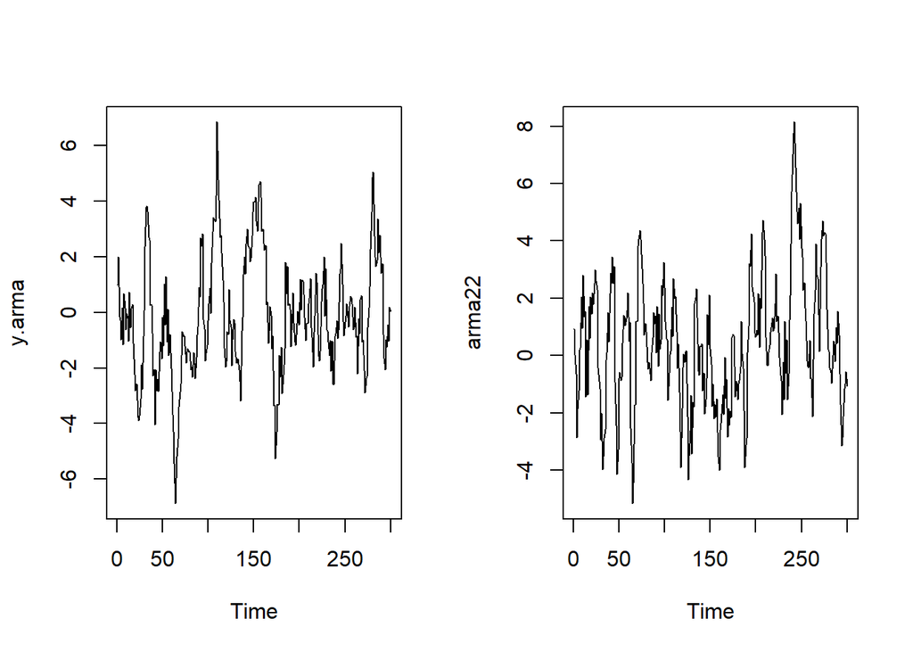

```r
par(mfrow = c(1, 2))
ts.plot(y.arma)
ts.plot(arma22)
```

```r
par(mfrow = c(1, 1))
```

Berdasarkan plot time series tersebut, terlihat bahwa model ARMA(2,2) cenderung stasioner dalam rataan

### Plot ACF

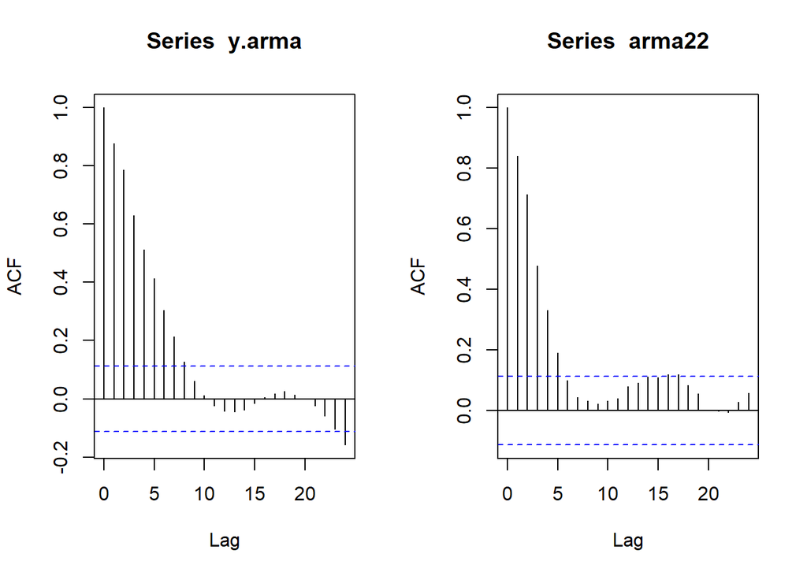

```r
par(mfrow = c(1, 2))
acf(y.arma)
acf(arma22)
```

```r
par(mfrow = c(1, 1))
```

Berdasarkan plot ACF tersebut, terlihat bahwa model ARMA(2,2) hasil simulasi memiliki plot ACF yang *tails off*, sesuai dengan teori yang ada

### Plot PACF

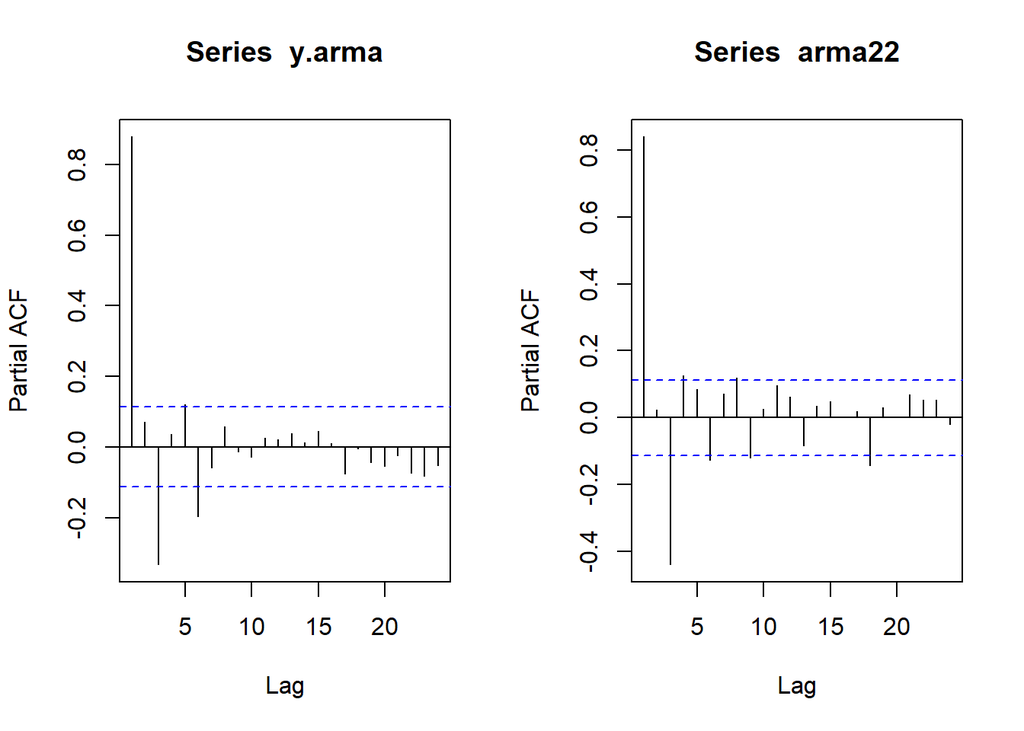

```r
par(mfrow = c(1, 2))
pacf(y.arma)
pacf(arma22)
```

```r
par(mfrow = c(1, 1))
```

Berdasarkan plot PACF tersebut, terlihat bahwa model ARMA(2,2) hasil simulasi memiliki plot PACF yang *tails off*, sesuai dengan teori

### Plot EACF

```r
TSA::eacf(y.arma)
```

```
## AR/MA
##   0 1 2 3 4 5 6 7 8 9 10 11 12 13
## 0 x x x x x x x x o o o  o  o  o
## 1 o x o o x o o o o o o  o  o  o
## 2 x x o o x o o o o o o  o  o  o
## 3 o x o o x o o o o o o  o  o  o
## 4 x x x o x o o o o o o  o  o  o
## 5 x x x x x x o o o o o  o  o  o
## 6 x x x o x o o o o o o  o  o  o
## 7 x x x o o o o o o o o  o  o  o
```

```r
TSA::eacf(arma22)
```

```
## AR/MA
##   0 1 2 3 4 5 6 7 8 9 10 11 12 13
## 0 x x x x x o o o o o o  o  o  o
## 1 o x o x o o o o o o o  o  o  o
## 2 o x x x o o o o o o o  o  o  o
## 3 x x x x o o o o o o o  o  o  o
## 4 x x o x x x o o o o o  o  o  o
## 5 x x o x x x o o o o o  o  o  o
## 6 x x x o o x o o o o x  o  o  o
## 7 x x x o o x x o o o o  o  o  o
```

### Scatterplot Antar Lag

#### Korelasi antara $Y_t$ dengan $Y_{t-1}$

```r
#Yt
yt_arma <- arma22[-1]
yt_arma
```

```
##   [1]  0.02325559 -0.62815799 -2.86880784 -1.87527716 -1.22147056  0.20303109
##   [7]  0.26274704  2.03717776  0.96329830  2.81058743  1.36447639  1.55028852
##  [13] -1.44929734  0.55194611 -1.36103414  1.71539847  0.60878462  2.05485961
##  [19]  1.44711357  2.17989132  1.77451014  2.51291232  2.99370050  2.62031781
##  [25]  2.29948362 -0.42525063 -0.66192175 -1.15449633 -2.92221718 -2.00714362
##  [31] -3.98558890 -3.52160371 -2.89495017 -2.57461016 -0.17151780  0.09546828
##  [37]  1.48980107  0.47721103  1.48231630  2.87329696  2.52300195  3.44397788
##  [43]  2.51649939  3.10061504 -0.92295157 -2.43875864 -4.13640275 -3.27657506
##  [49] -0.79784111 -0.58796071 -0.86384657 -0.76126397  0.42201948  1.39754790
##  [55]  1.35746682  1.04387802  1.29516570  1.57966180  2.18215912  0.49891560
##  [61]  1.17523223 -2.52104947 -3.73305938 -5.16274323 -4.44220813 -1.72094409
##  [67] -1.72833277  1.19924753  1.19019982  3.81356912  4.05725307  4.37469891
##  [73]  4.06785812  3.53613962  2.51435934  1.82922143  0.71011049  1.10987987
##  [79]  0.82630817 -0.22431669 -0.47531120 -0.22773534 -0.63599616 -0.87892479
##  [85]  0.10012514  0.61934229  1.50341715  1.09486132  1.38471259  0.08958971
```

[output cut: 35 more lines]

```r
#Yt-1
yt_1_arma <- arma22[-300]
yt_1_arma
```

```
##   [1]  0.92530526  0.02325559 -0.62815799 -2.86880784 -1.87527716 -1.22147056
##   [7]  0.20303109  0.26274704  2.03717776  0.96329830  2.81058743  1.36447639
##  [13]  1.55028852 -1.44929734  0.55194611 -1.36103414  1.71539847  0.60878462
##  [19]  2.05485961  1.44711357  2.17989132  1.77451014  2.51291232  2.99370050
##  [25]  2.62031781  2.29948362 -0.42525063 -0.66192175 -1.15449633 -2.92221718
##  [31] -2.00714362 -3.98558890 -3.52160371 -2.89495017 -2.57461016 -0.17151780
##  [37]  0.09546828  1.48980107  0.47721103  1.48231630  2.87329696  2.52300195
##  [43]  3.44397788  2.51649939  3.10061504 -0.92295157 -2.43875864 -4.13640275
##  [49] -3.27657506 -0.79784111 -0.58796071 -0.86384657 -0.76126397  0.42201948
##  [55]  1.39754790  1.35746682  1.04387802  1.29516570  1.57966180  2.18215912
##  [61]  0.49891560  1.17523223 -2.52104947 -3.73305938 -5.16274323 -4.44220813
##  [67] -1.72094409 -1.72833277  1.19924753  1.19019982  3.81356912  4.05725307
##  [73]  4.37469891  4.06785812  3.53613962  2.51435934  1.82922143  0.71011049
##  [79]  1.10987987  0.82630817 -0.22431669 -0.47531120 -0.22773534 -0.63599616
##  [85] -0.87892479  0.10012514  0.61934229  1.50341715  1.09486132  1.38471259
```

[output cut: 35 more lines]

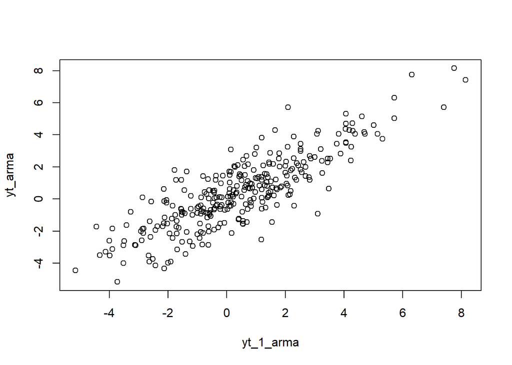

```r
plot(y=yt_arma,x=yt_1_arma)
```

Berdasarkan scatterplot tersebut, terlihat bahwa terdapat hubungan positif antara $Y_t$ dengan $Y_{t-1}$. Hal ini sesuai dengan teori yang ada

```r
cor(yt_arma,yt_1_arma)
```

```
## [1] 0.8415146
```

## Korelasi antara $Y_t$ dengan $Y_{t-2}$

```r
#Yt
yt_arma2 <- arma22[-c(1,2)]
#Yt-2
yt_2_arma <- arma22[-c(299,300)]
```

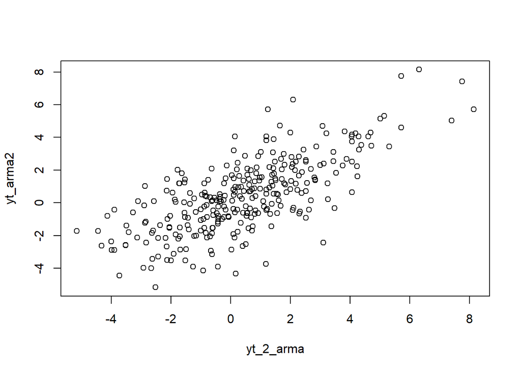

```r
plot(y=yt_arma2,x=yt_2_arma)
```

Berdasarkan scatterplot tersebut, terlihat bahwa terdapat hubungan positif antara $Y_t$ dengan $Y_{t-2}$. Hal ini sesuai dengan teori yang ada

```r
cor(yt_arma2,yt_2_arma)
```

```
## [1] 0.7148256
```

## Korelasi antara $Y_t$ dengan $Y_{t-3}$

```r
#Yt
yt_arma3 <- arma22[-c(1,2,3)]
#Yt-3
yt_3_arma <- arma22[-c(298,299,300)]
```

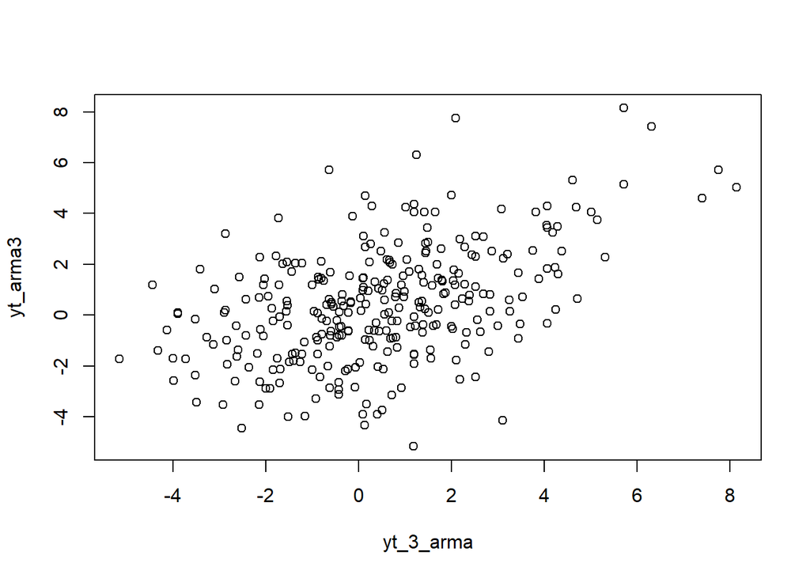

```r
plot(y=yt_arma3,x=yt_3_arma)
```

Berdasarkan scatterplot tersebut, terlihat bahwa terdapat hubungan positif antara $Y_t$ dengan $Y_{t-3}$. Hal ini sesuai dengan teori yang ada

```r
cor(yt_arma3,yt_3_arma)
```

```
## [1] 0.4782824
```